# proDA analysis of Virology data (proteins interaction - BioID data)

Philippe Hauchamps

December 18th, 2019

## Goal of this report

The goal of this report is to analyze protein intensity data from a Virology BioID protein interaction experiment.

Input data are taken from a set of files processed by MaxQuant platform. Here we concentrate on the so-called ‘R’ experiment and consider 2 different conditions :

- Wild Type (WT)
- Mutated M60V

There might be a batch effect, since among the 3 replicates per condition, one was produced first, and the two others in a subsequent batch.

M60V serves as negative control and should be compared against the WT condition, where we would like to identify the differentially abundant proteins.

Questions of interest :

- which proteins are significantly differentially abundant in WT vs. M60V ?
- among these, do we see an enrichment for the proteins belonging to FG-NUP group? (see below for a definition of this group)

In order to cope with high proportion of missing data (not at random), we use the proDA package which :

- belongs to the class of empirical bayes methods
- models the missingness process explicitly, and link it to the latent protein intensities.

## Read MaxQuant data - build MSnSet object

While importing the MaxQuant data into an MSnSet object, we filter out :

- identified contaminants
- identified reverse sequences
- proteins which do not have any positive intensity for any sample.

After filtering, we obtain intensities for 1397 proteins.

We check that we have 6 samples, i.e. 2 conditions and 3 replicates per condition.

```r
f <- "data/MQ20191213/combined/proteinGroups.txt"
#getEcols(f, "\t")

## e <- grepEcols(f, "LFQ ", "\t")
e <- grepEcols(f, "Intensity ", "\t")
# Make MSnSet object
x <- readMSnSet2(f, ecol = e, sep = "\t")
sampleNames(x) <- sub("Intensity.", "", sampleNames(x))
pData(x)$rep <- rep(1:3, 2)
pData(x)$grp <- rep(c("M60V", "WT"), each = 3)
pData(x)$grp <- factor(pData(x)$grp, levels = c("M60V", "WT"))
pData(x)$batch <- rep(c(1, 2, 2), 2)

featureNames(x) <- fData(x)$Protein.IDs

## Remove contaminants, reverse and no expression
## changed: was ^CON and ^REV
x <- x[-grep("CON", fData(x)[, "Protein.IDs"])]
x <- x[-grep("REV", fData(x)[, "Protein.IDs"])]
x <- x[rowSums(exprs(x)) > 0, ]
nSamples <- nrow(pData(x))
nProteins <- nrow(x)
cat("nSamples : ", nSamples, "\n")
```

```
## nSamples :  6
```

```r
cat("nProteins : ", nProteins, "\n")
```

```
## nProteins :  1397
```

## Some exploratory data analysis

### PCA via pRoloc::plot2D

We compute a preliminary PCA, and display the scores of the samples on 2D projections.

These projections are difficult to interpret. A batch effect (replicate 1 vs. 2 and 3) seems to be present for condition M60V but is less evident for WT.

It seems also difficult to show a clear separation of M60V samples vs. WT when looking at the components 2D projections.

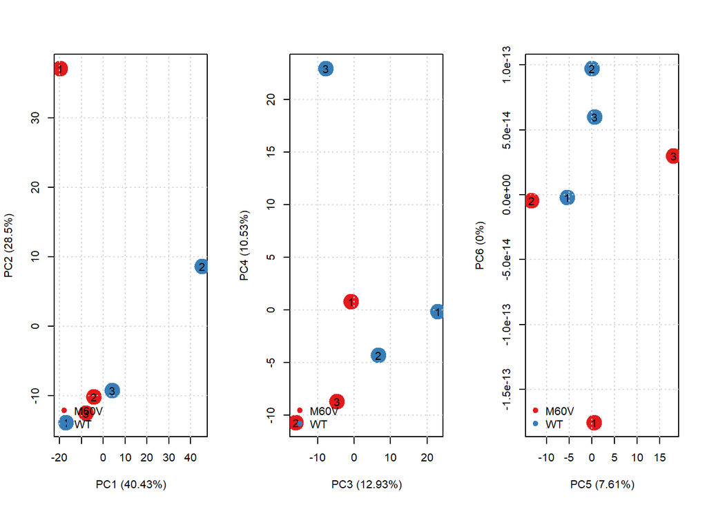

```r
par( mfrow = c(1,3) )
#plot2D(normalise(x, "sum"), fcol = NULL)

.pca <- plot2D(t(x),  fcol = "grp", cex = 3, dims = 1:2)
text(.pca[, 1], .pca[, 2], 1:3)
addLegend(t(x), fcol = "grp")
.pca <- plot2D(t(x),  fcol = "grp", cex = 3, dims = 3:4)
text(.pca[, 1], .pca[, 2], 1:3)
addLegend(t(x), fcol = "grp")
.pca <- plot2D(t(x),  fcol = "grp", cex = 3, dims = 5:6)
text(.pca[, 1], .pca[, 2], 1:3)
addLegend(t(x), fcol = "grp")
```

### boxplot and density of log( intensities )

Strangely, it seems that WT1 showed much more NA’s than the other samples, which is not what we would expect. WT2 also shows a strange pattern in terms of densities.

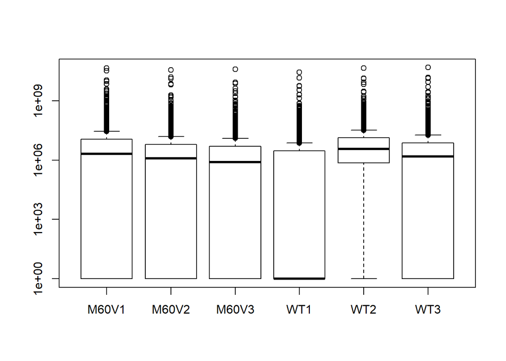

```r
par( mfrow = c(1,1) )
boxplot(exprs(x)+1, log = "y")
```

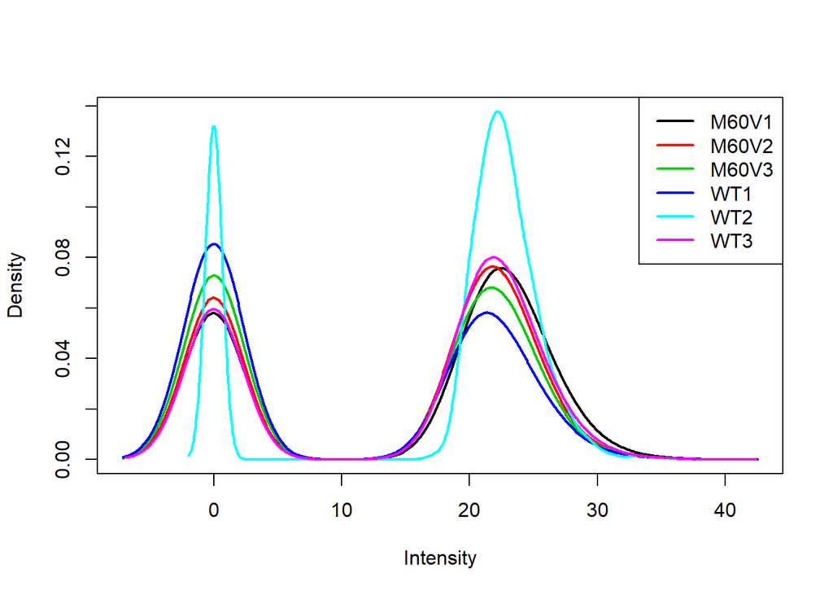

```r
limma::plotDensities(log2(exprs(x) + 1),
                     legend = "topright")
```

### NA’s per sample

We have 37% of missing data. As expected, we have less missing data for the WT, but only for replicate 2 and 3. As mentioned already, replicate 1 for WT condition does not show the expected pattern when compared to replicate 1 for M60V (which is supposed to be the negative control).

```r
# Replace 0 by NA
exprs(x)[exprs(x) == 0] <- NA
pData(x)$nNA <- colSums(is.na(exprs(x)))
fData(x)$nNA <- rowSums(is.na(exprs(x)))

cat("NA's : ", round( 100 * mean( is.na(x) ), 2 ), "%\n" )
```

```
## NA's :  37.02 %
```

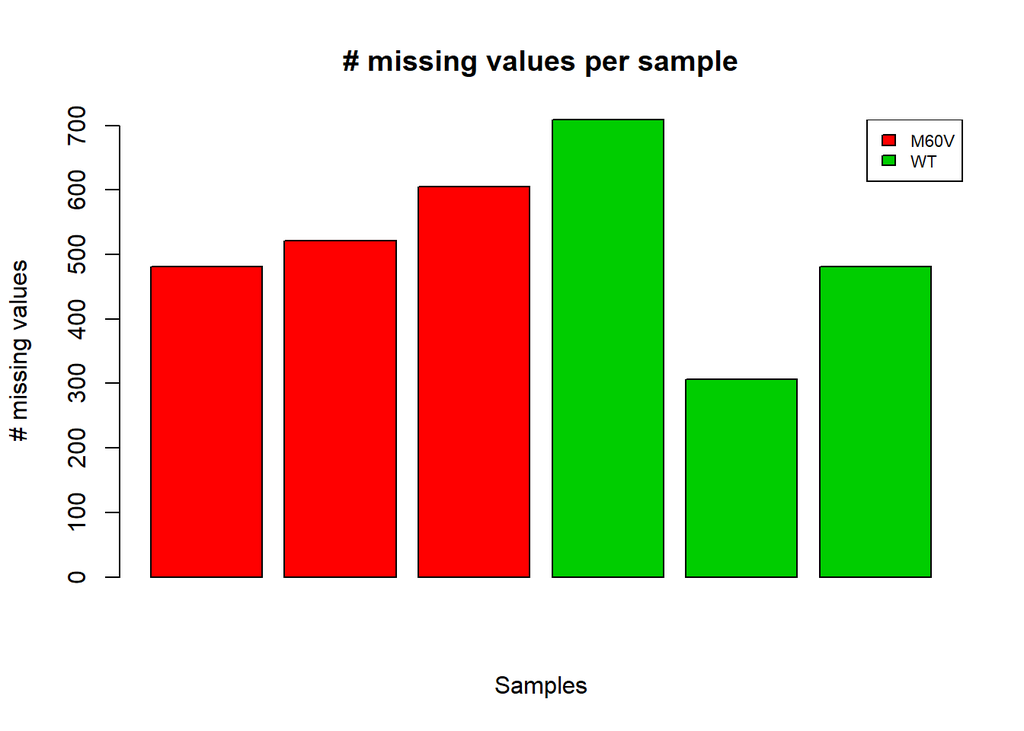

```r
barplot(pData(x)$nNA,
        ylab = "# missing values",
        xlab = "Samples",
        main = "# missing values per sample",
        col = rep(c(2, 3, 4), each = 3))
legend("topright",
       legend=unique( pData( x )$grp ),
       cex = 0.7,
       fill = c(2, 3, 4))
```

## proDA analysis after normalization

We normalize the log2 transformed sample data using translation wrt column (sample) median. We also add a constant, in order to avoid displaying negative values.

```r
norm_log_x <- x %>%
    log(base = 2) %>%
    normalise(method = "center.median" )
exprs(norm_log_x) <- exprs(norm_log_x) + 5 ## to remove negative values
```

We then run proDA analysis on log2 transformed data.  
We run one model fit with only ‘group’ (M60V vs. WT) as covariate and another model with both ‘group’ and ‘batch’ as covariates.

```r
file_name <- "rds/proDA_fit_norm_3grp_Rexp.rds"
if ( file.exists( file_name )) {
    proDA_fit_norm <- readRDS( file_name )
} else {

    proDA_fit_norm <- proDA( norm_log_x,
                            design = ~ grp,
                            data_is_log_transformed = TRUE,
                            verbose = TRUE)

    saveRDS( proDA_fit_norm, file = file_name )
}

file_name <- "rds/proDA_fit_full_norm_3grp_Rexp.rds"
if ( file.exists( file_name )) {
    proDA_fit_full_norm <- readRDS( file_name )
} else {
    proDA_fit_full_norm <- proDA( norm_log_x,
                                 design = ~ grp + batch,
                                 data_is_log_transformed = TRUE,
                                 verbose = TRUE)

    saveRDS( proDA_fit_full_norm, file = file_name )
}
```

### Test of the batch effect

From the full model, we test whether the batch effect is significant. First ajusted p-vals are around 0.61. We can therefore remove the batch covariate from the model.

```r
batch_res <- test_diff( proDA_fit_full_norm,
                        contrast = "batch",
                        alternative = "two.sided",
                        pval_adjust_method = "BH",
                        sort_by = "pval" )
head(dplyr::arrange(batch_res, adj_pval))
```

```
##     name        pval  adj_pval      diff t_statistic        se df
## 1 Q9UNZ2 0.001602710 0.6073218  4.320458   11.014347 0.3922573  3
## 2 Q9NZT1 0.002037407 0.6073218 -5.175129  -10.150187 0.5098555  3
## 3 Q96DA0 0.002181999 0.6073218 -9.319790   -9.915457 0.9399254  3
## 4 P01040 0.002921275 0.6073218 -3.407433   -8.973001 0.3797429  3
## 5 P05109 0.004408225 0.6073218 -4.404727   -7.786350 0.5656985  3
## 6 O75369 0.004821846 0.6073218  2.907592    7.547868 0.3852203  3
##   avg_abundance n_approx n_obs
## 1      5.303167 6.000000     6
## 2      5.402889 4.939887     5
## 3      2.312489 2.855447     3
## 4      5.860791 6.000000     6
## 5      7.995411 6.000000     6
## 6      7.548158 6.000000     6
```

### Wald test of WT vs M60V

Here we test (in the reduced model) whether the group difference WT vs M60V is significant. We opt for a one-sided test as we know that WT group should have greater intensities, M60V being the negative control. We get :

- smallest p-vals around 5e-04 and adjusted p-val between 0.43 and 0.61
- When looking at the p-values, we find some proteins that are significantly differentially abundant, and btw they are part of FG-NUP group
- however the multiple test correction provides adjusted p-values which are not significant at 5% level. This could probably be due to a data issue with WT Replicate 1

```r
grp_res <- test_diff( proDA_fit_norm,
                       contrast = "grpWT",
                       alternative = "greater",
                       pval_adjust_method = "BH",
                       sort_by = NULL,
                       verbose = F )

dplyr::arrange(grp_res, adj_pval) %>%
    head()
```

```
##                   name         pval  adj_pval     diff t_statistic
## 1 A8CG34;A6NF01;Q6PJE2 0.0005123173 0.4293195 4.188516    8.555735
## 2               O15504 0.0006146307 0.4293195 4.646724    8.157380
## 3               P37198 0.0015535099 0.5583411 3.383806    6.374219
## 4               P52948 0.0015986862 0.5583411 3.521009    6.324999
## 5               O60318 0.0032581148 0.6138136 3.070698    5.199981
## 6               Q14974 0.0035150384 0.6138136 3.051809    5.090281
##          se df avg_abundance n_approx n_obs
## 1 0.4895565  4      5.852357 4.989765     5
## 2 0.5696343  4      6.040841 3.969576     4
## 3 0.5308582  4      6.967212 6.000000     6
## 4 0.5566813  4     10.067764 6.000000     6
## 5 0.5905209  4      8.382721 6.000000     6
## 6 0.5995365  4      3.543906 3.662411     4
```

Let’s now define the FG-NUP group :

```r
FGNupGroup <- c("RANBP2",
                "NUP214",
                "NUPL2",
                "NUP62",
                "NUP54",
                "NUPL1",
                "NUP98",
                "POM121",
                "POM121C",
                "NUP153",
                "NUP50")
kable(FGNupGroup)
```

| x |
| --- |
| RANBP2 |
| NUP214 |
| NUPL2 |
| NUP62 |
| NUP54 |
| NUPL1 |
| NUP98 |
| POM121 |
| POM121C |
| NUP153 |
| NUP50 |

We can still display a volcano plot wrt to the WT vs. M60V statistical test, with no significant proteins, but where we still highlight the FG-NUP proteins.

We can see that the FG-NUP proteins seems to be well represented in the highest fold changes.

```r
plotVolcano <- function(tstResults,
                        alpha,
                        # set to highlight on the graph
                        # if null => statistically signif. will be highlighted
                        set2Highlight = NULL,
                        highlightColor = "red",
                        displayHighlightedNames = FALSE
                        ) {
  if( !is.null(set2Highlight)){
    highLighted <- tstResults$set == set2Highlight
  }
  else
  {
    highLighted <- tstResults$adj_pval <= alpha
  }

  plot( x = tstResults$diff,
      y = -log10(tstResults$adj_pval),
      col = ifelse( highLighted, highlightColor, "grey"),
      xlab = "lfc",
      ylab = "-log10(pvalue)",
      main = paste( "Diff. protein abundance (alpha =",alpha,")" )
    )

  abline( h = -log10(alpha), col = "red", lty = 2 )

  if(displayHighlightedNames){
    names <- as.character(tstResults$name)
    text(tstResults$diff,
      -log10(tstResults$adj_pval),
      ifelse(highLighted, names, ""),
      cex = 0.6,
      pos = 4,
      col = highlightColor,
      offset = 0.5)
  }
}
```

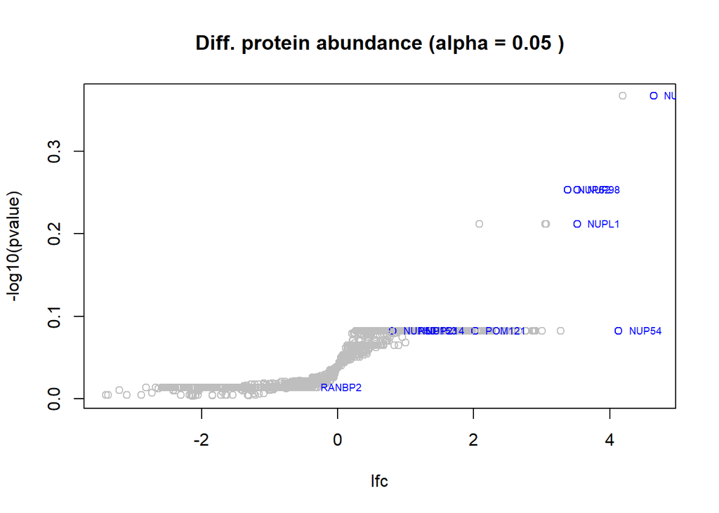

```r
proteins_res <- grp_res
proteins_res$name <- fData( norm_log_x )$Gene.names
proteins_res$set <- as.factor(ifelse(proteins_res$name %in% FGNupGroup,
                                     "FG-NUP",
                                     "Not_FG-NUP"))

alpha <- 0.05

plotVolcano(proteins_res,
            alpha,
            set2Highlight = "FG-NUP",
            highlightColor = "blue",
            displayHighlightedNames = TRUE
            )
```

The below shows the histogram of p-values. These seems to be roughly uniformly distributed.

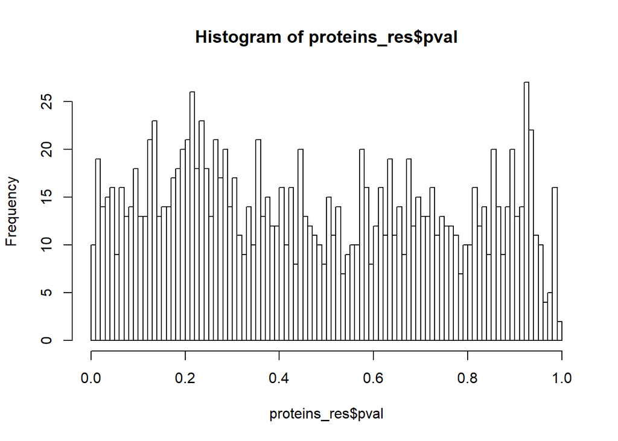

```r
hist(proteins_res$pval, breaks = 100)
```

## Over Representation Analysis of the FG-NUP protein group (WT vs M60V)

There is no point in using the Fisher test for Over Representation analysis since there is no identified statistically significant proteins when taking the FDR control (multiple test correction) into account.

### Using GSEA

We implement here a procedure similar to what is implemented in GSEA (for ‘Gene Set Enrichment Analysis’) software (see reference [1]).

We first calculate the Enrichment Score as well as showing the Enrichment Score path. The score is equal to 1055.3. The Enrichment Score path shows a steep increase for the first proteins. Note that each proteins belonging to FG-NUP group adds 138.7 units to the score, while each proteins not belonging to FG-NUP group substract only one unit to the score.

```r
# the following function calculates an enrichment score (as in
# ref. [1] based a list of proteins with their pro-DA p-value (sorted
# according to decreasing p-value), and their set tags.
get_enrichment_score <- function(proteins_res, set) {
  ## order results set
    proteins_res <- proteins_res[ order( proteins_res$pval, decreasing = FALSE ), ]
    n_proteins <- nrow( proteins_res )
    n_proteins_in_set <- sum( proteins_res$set == set )
    set_ratio <- (n_proteins - n_proteins_in_set) / n_proteins_in_set
    set_indicators <- 1 * (proteins_res$set == set)
    prot.contributions <- -1 * rep(1, n_proteins) + (1 + set_ratio) * set_indicators
    path <- cumsum( prot.contributions )
    ES <- max( path )
    return( list( ES_path = path, ES = ES ) )
}
```

```r
ret <- get_enrichment_score( proteins_res, set = "FG-NUP" )
the_ES <- ret$ES
the_ES
```

```
## [1] 1055.3
```

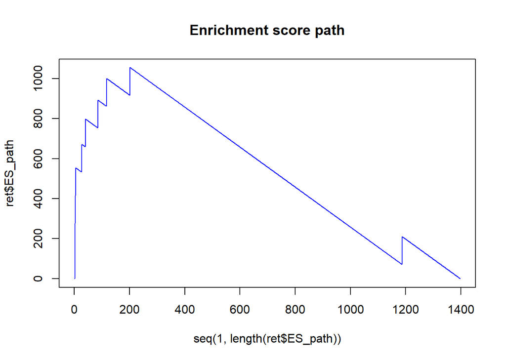

```r
#ret$ES_path

par( mfrow = c(1,1) )
plot( x = seq( 1, length( ret$ES_path ) ),
      y = ret$ES_path,
      type = "l",
      col = "blue",
      main = "Enrichment score path" )
```

```r
# the following function :
# - creates a random permutation of two sample groups (or identity permutation if 'do_permutation' == FALSE)
# - fits the proDA analysis based on the newly assigned abundances (including NA's)
# - calculates the p-val of the differential analysis for each gene
# - orders the gene by decreasing order of p-val (not adjusted)
# - calculates the Enrichment score as described in Ref. [2]

# input : 'experiment' : a MSnSet object containing the experiment data
#         'set' : the set variable (as a factor) for which to compute an enrichment score
#         'seed' : starting seed to generate the Monte Carlo simulation from
#         'contrast' : the contrast character to be used in the statistical test
one_permutation_enrichment_score <- function(experiment,
                                             set,
                                             seed,
                                             contrast,
                                             filePrefix,
                                             do_permutation = TRUE){
  set.seed(seed)

  groups <- pData(experiment)$grp
  nSamples <- length(groups)
  groupNames <- unique(groups)
  nGroups <- length(groupNames)

  groupSamples <- list()
  nInGroup <- rep(0L, nGroups)

  for(i in 1:nGroups){
    groupSamples[[i]] <- which(groups == groupNames[i])
    nInGroup[i] <- length(groupSamples[[i]])
  }

  # generate one permutation between all the groups
  permGroupSamples <- list()
  # keep the number of samples per group same as originally
  if ( do_permutation ) {
    samplesOrder <- sample(1:nSamples, nSamples, replace = FALSE)
    currentIndex <- 0
    for(i in 1:nGroups){
      permGroupSamples[[i]] <- samplesOrder[currentIndex
                                          + (1:nInGroup[i])]
      currentIndex <- currentIndex + nInGroup[i]
      permGroupSamples[[i]] <- sort(permGroupSamples[[i]])
    }

  } else {
    permGroupSamples <- groupSamples
  }

  permuted_experiment <- experiment
  for(i in 1:nGroups){
    pData(permuted_experiment)$grp[permGroupSamples[[i]]] <- groupNames[i]
  }
  #pData(permuted_experiment)

  # calling the proDA machinery

  suffix <- paste(permGroupSamples[[1]], collapse = "_")
  for(i in 2:nGroups){
    suffix <- paste0(suffix, "__")
    suffix <- paste0(suffix, paste(permGroupSamples[[i]], collapse = "_"))
  }
  file_name <- paste0( filePrefix, suffix, ".rds" )
  #file_name <- paste0( "./rds/GSEA/3groups/proDA_fit_norm_perm_", suffix, ".rds" )

  if (file.exists(file_name)){
    proDA_fit_norm_perm <- readRDS(file_name)
  } else {
    cat(" Running proDA model fitting with permutation", suffix, "\n")
    cat(" ***************************************************")
    proDA_fit_norm_perm <- proDA(permuted_experiment,
                                 design = ~ grp,
                                 data_is_log_transformed = TRUE,
                                 verbose = TRUE)

    saveRDS(proDA_fit_norm_perm, file = file_name)
  }

  # getting the proDA results
  perm_res <- test_diff( proDA_fit_norm_perm,
                       contrast = contrast,
                       alternative = "greater",
                       pval_adjust_method = "BH",
                       sort_by = NULL,
                       verbose = FALSE)
  perm_res$name <- fData(experiment)$Gene.names
  perm_res$set <- set
  ret <- get_enrichment_score(perm_res, set = levels(set)[1])
  ret
}
```

The permutation test shows that among all possible sample permutations - 20 different permutations - , the actual data have the highest enrichment score for the FG-Nup group.

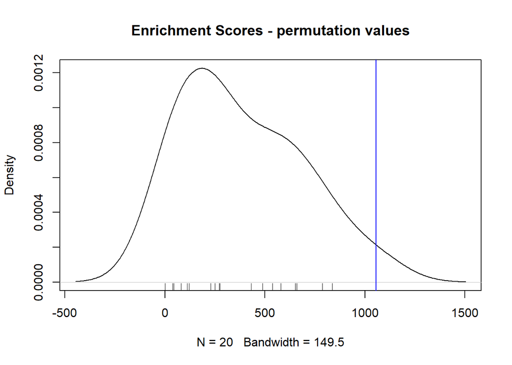

```r
file_name <- "./rds/GSEA/2groupsR/permutation_test_enrichscores_WT_vs_M60V.rds"
filePrefix <- "./rds/GSEA/2groupsR/proDA_fit_norm_perm_"
mySeed <- 20190512

if ( file.exists( file_name )) {
  ER_sample <- readRDS( file_name )
} else {
  n_permutations <- 100
  ER_sample <- rep(0, n_permutations)
  for (i in 1:n_permutations) {
      seed <- mySeed + i
      ret <- one_permutation_enrichment_score(norm_log_x,
                                              set = proteins_res$set,
                                              seed = seed,
                                              contrast = "grpWT",
                                              filePrefix = filePrefix,
                                              do_permutation = TRUE)
      ER_sample[i] <- ret$ES
  }

  saveRDS( ER_sample, file_name )
}

#hist( ER_sample, main = "Enrichment Score p-value")

#max( ER_sample )
ERS <- sort( unique( ER_sample ) )
## hist( ERS, main = "Enrichment Scores - permutation values")
plot( density(ERS), main = "Enrichment Scores - permutation values")
rug(ERS)
abline( v = the_ES, col = "blue" )
```

## Export final results

Full export: normalised data and proDA results (for shiny app)

```r
fd <- fData(norm_log_x)[, c("Protein.IDs",
                            "Protein.names",
                            "Gene.names",
                            "nNA")]
norm_log_x1 <- norm_log_x
fd1 <- dplyr::full_join(fd, proteins_res, by = c("Gene.names" = "name"))
fd1 <- fd1[!duplicated(fd1[[1]]),]
rownames(fd1) <- fd1[[1]]
fData(norm_log_x1) <- fd1
res1 <- ms2df(norm_log_x1)
res1$set[res1$set == "Not_FG-NUP"] <- NA
saveRDS(res1, file = "rds/res_expR_WT_vs_M60V.rds")
```

## References

[1] Subramanian, Aravind, Pablo Tamayo, Vamsi K. Mootha, Sayan Mukherjee, Benjamin L. Ebert, Michael A. Gillette, Amanda Paulovich, et al. 2005. “Gene Set Enrichment Analysis: A Knowledge-Based Approach for Interpreting Genome-Wide Expression Profiles.” Proceedings of the National Academy of Sciences of the United States of America 102 (43): 15545-50.